# DotA Analysis for OMEGA League: Americas Divine Division

Conner ‘Mathmagician10’ Chapman

# Introduction

Hey guys, I’m [Mathmagician10](https://www.twitch.tv/mathmagician10). I am an amateur caster who is looking to use my statistics degree for more than just my day job, so I created this team analysis in [R](https://www.rstudio.com/) with what feels like a million datasets from [DatDota](https://www.datdota.com/). I hope you guys enjoy what you read. I’m hoping this makes the draft stage a little more fun for you guys to watch since you could have a better idea of what is coming. I’ll take any and all suggestions/criticisms as I would love to know what I can do to be better. For today’s analysis, we have the **OMEGA League: Americas Divine Division.**

p.s. - Ωmega Gaming, I don’t know why you have an Ω in your official name, but it makes things really annoying.

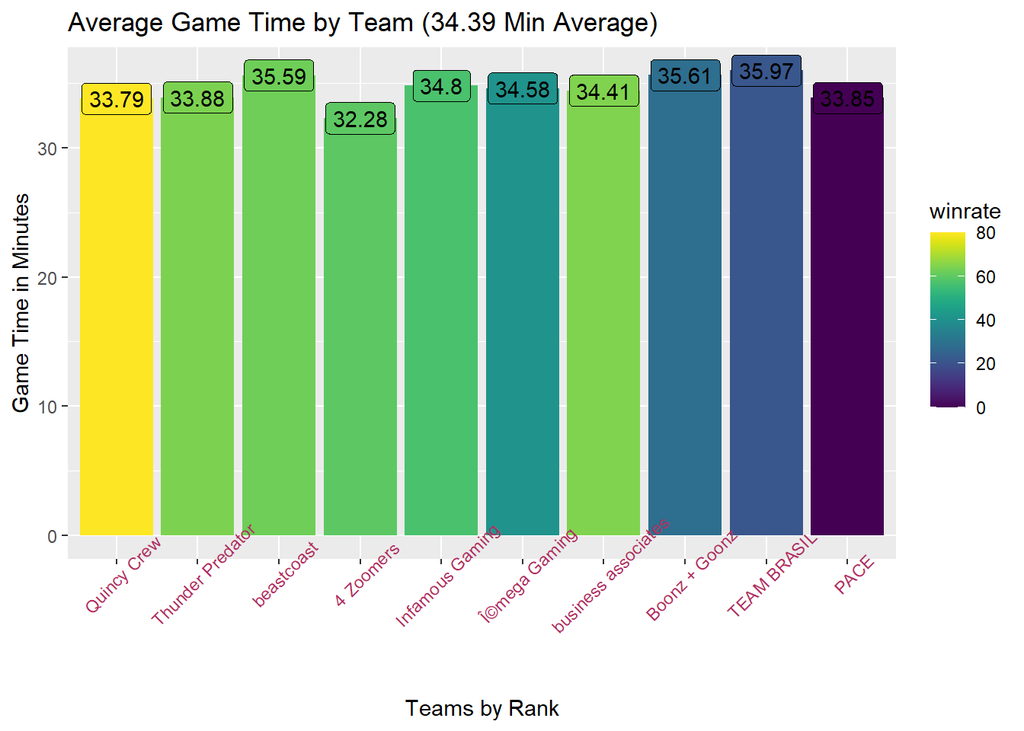

This shows the average game time in minutes for each of the teams in the tournament. The win rate for each team is scaled on the right by color, and shows a decent bell curve for the win rates of all teams.

## The Top 3

The following data will be split into three sections, one for each phase. The goal will be to determine what the expected picks and bans will be solely based off of statistics, not necessarily previous games or previous pick/bans. Inherently, this makes the first phase draft data the most impactful as you will likely dedicate one of your first bans to taking away high priority heroes on the other team. Typically these are not in reaction to the other bans you would have already seen.

[figure not shown]

### Quincy Crew

Quincy Crew has gone on a reign of terror from the start. After dropping only one game to Business Associates in the group stage, Quincy have gone on a tear, dropping only one game each to Beastcoast and 4 Zoomers. Here’s what we can expect from the Quincy Crew draft in the Grand Finals.

#### First Phase

| hero_name | total_picks | top_phase | role_type | pick_win_pct | Winrate | winrate_delta |
| --- | --- | --- | --- | --- | --- | --- |
| Void Spirit | 17 | 1st Phase | Core | 88.24 | 52.46 | 35.78 |
| Ember Spirit | 14 | 1st Phase | Core | 71.43 | 48.73 | 22.70 |
| Mirana | 14 | 1st Phase | Support | 85.71 | 60.17 | 25.54 |
| Nature’s Prophet | 13 | 1st Phase | Core | 76.92 | 55.00 | 21.92 |
| Phoenix | 13 | 1st Phase | Support | 69.23 | 48.16 | 21.07 |
| Clockwerk | 10 | 1st Phase | Support | 70.00 | 53.61 | 16.39 |
| Elder Titan | 10 | 1st Phase | Support | 100.00 | 54.79 | 45.21 |
| Rubick | 10 | 1st Phase | Support | 80.00 | 43.35 | 36.65 |
| Venomancer | 10 | 1st Phase | Support | 80.00 | 58.79 | 21.21 |
| Tiny | 9 | 1st Phase | Support | 77.78 | 52.06 | 25.72 |

As we can see, Quinn is an absolute FIEND. Both the Void Spirit and the Ember Spirit are most likely to be first rounded, and at a 88.24% winrate and 71.43% winrate respectively. Now that we only have two bans in the first stage of Captains Mode, I would expect to see both Void and Ember Spirit being banned against Quincy Crew.

#### Second Phase

| hero_name | total_picks | top_phase | role_type | pick_win_pct | Winrate | winrate_delta |
| --- | --- | --- | --- | --- | --- | --- |
| Axe | 12 | 2nd Phase | Support | 83.33 | 51.11 | 32.22 |
| Witch Doctor | 9 | 2nd Phase | Support | 100.00 | 47.06 | 52.94 |
| Winter Wyvern | 6 | 2nd Phase | Support | 83.33 | 55.17 | 28.16 |
| Doom | 3 | 2nd Phase | Core | 66.67 | 53.22 | 13.45 |
| Nyx Assassin | 3 | 2nd Phase | Support | 66.67 | 50.00 | 16.67 |
| Jakiro | 1 | 2nd Phase | Support | 0.00 | 40.30 | -40.30 |
| Keeper of the Light | 1 | 2nd Phase | Support | 100.00 | 40.91 | 59.09 |
| Oracle | 1 | 2nd Phase | Support | 0.00 | 52.11 | -52.11 |
| Vengeful Spirit | 1 | 2nd Phase | Support | 0.00 | 57.06 | -57.06 |

I would suggest only taking Axe, Witch Doctor, and Winter Wyvern into account when looking at their second phase picks. All others have less than five games picked in patch 7.27. If going entirely for a draft that denies Quincy Crew their typical high-winrate heroes, these would be the three heroes to bounce out of the pool. Especially with Lelis rocking a 70.83% winrate on Axe (83.33% in 7.27 - 7.23 over 12 games).

#### Third Phase

| hero_name | total_picks | top_phase | role_type | pick_win_pct | Winrate | winrate_delta |
| --- | --- | --- | --- | --- | --- | --- |
| Faceless Void | 11 | 3rd Phase | Core | 90.91 | 54.29 | 36.62 |
| Lina | 8 | 3rd Phase | Core | 87.50 | 49.56 | 37.94 |
| Morphling | 8 | 3rd Phase | Core | 62.50 | 54.61 | 7.89 |
| Terrorblade | 8 | 3rd Phase | Core | 87.50 | 51.36 | 36.14 |
| Spectre | 7 | 3rd Phase | Core | 85.71 | 48.03 | 37.68 |
| Gyrocopter | 6 | 3rd Phase | Core | 100.00 | 61.76 | 38.24 |
| Invoker | 6 | 3rd Phase | Core | 66.67 | 52.27 | 14.40 |
| Centaur Warrunner | 5 | 3rd Phase | Support | 80.00 | 46.67 | 33.33 |
| Legion Commander | 5 | 3rd Phase | Support | 80.00 | 48.20 | 31.80 |
| Medusa | 5 | 3rd Phase | Core | 40.00 | 41.18 | -1.18 |

Back to top

### Thunder Predator

[figure not shown]

Thunder Predator showed a strong start in their group stage, recording their only two game losses in their series loss to Beastcoast. After coming out of the group stage 7-2, they immediatly dropped to the lower bracket due to a 0-2 loss from 4 Zoomers. On the back of two different three-game series wins, they will be facing their nemesis 4 Zoomers again to fight their way back to the Grand Finals. Here is what to expect from their draft.

#### First Phase

| hero_name | total_picks | top_phase | role_type | pick_win_pct | Winrate | winrate_delta |
| --- | --- | --- | --- | --- | --- | --- |
| Vengeful Spirit | 15 | 1st Phase | Support | 66.67 | 57.06 | 9.61 |
| Clockwerk | 14 | 1st Phase | Support | 64.29 | 53.61 | 10.68 |
| Ember Spirit | 14 | 1st Phase | Core | 64.29 | 48.73 | 15.56 |
| Nature’s Prophet | 13 | 1st Phase | Core | 84.62 | 55.00 | 29.62 |
| Rubick | 13 | 1st Phase | Support | 38.46 | 43.35 | -4.89 |
| Batrider | 11 | 1st Phase | Support | 90.91 | 54.84 | 36.07 |
| Void Spirit | 11 | 1st Phase | Core | 54.55 | 52.46 | 2.09 |
| Tiny | 10 | 1st Phase | Support | 60.00 | 52.06 | 7.94 |
| Earth Spirit | 9 | 1st Phase | Support | 77.78 | 55.43 | 22.35 |
| Venomancer | 9 | 1st Phase | Support | 77.78 | 58.79 | 18.99 |

Contrary to the drafting style of Quincy Crew, the top two picks from Thunder Predator are supports. Two strong, BKB piercing stunners show that Thunder Predator will draft to lock you down. Don’t be thrown off by that Ember Spirit , this could either be a Leostyle hero (16 games, 62.5% winrate since 7.23) or even a Matthew position 4 special (17 games, 64.71% winrate since 7.24). With a low range of top ten 1st phase expected picks, I would expect to see hard lockdown from Vengeful Spirit and Clockwerk banned in the first phase versus Thunder Predator.

#### Second Phase

| hero_name | total_picks | top_phase | role_type | pick_win_pct | Winrate | winrate_delta |
| --- | --- | --- | --- | --- | --- | --- |
| Centaur Warrunner | 5 | 2nd Phase | Support | 60.00 | 46.67 | 13.33 |
| Lina | 5 | 2nd Phase | Core | 80.00 | 49.56 | 30.44 |
| Tusk | 3 | 2nd Phase | Support | 0.00 | 36.56 | -36.56 |
| Undying | 3 | 2nd Phase | Support | 33.33 | 48.04 | -14.71 |
| Crystal Maiden | 1 | 2nd Phase | Support | 0.00 | 49.25 | -49.25 |
| Grimstroke | 1 | 2nd Phase | Support | 100.00 | 46.88 | 53.12 |
| Leshrac | 1 | 2nd Phase | Core | 100.00 | 41.67 | 58.33 |
| Mirana | 1 | 2nd Phase | Support | 100.00 | 60.17 | 39.83 |
| Monkey King | 1 | 2nd Phase | Core | 100.00 | 55.17 | 44.83 |
| Necrophos | 1 | 2nd Phase | Core | 0.00 | 51.39 | -51.39 |

As you can see from the table above, only Centaur Warrunner and Lina have five picks around the second phase, and all other heroes are at three or less games total. In phase two versus Thunder Predator, I would imagine most picks and bans will be to protect the draft of the team against them which are not necessarily with the intent to deny picks.

#### Third Phase

| hero_name | total_picks | top_phase | role_type | pick_win_pct | Winrate | winrate_delta |
| --- | --- | --- | --- | --- | --- | --- |
| Legion Commander | 14 | 3rd Phase | Support | 64.29 | 48.20 | 16.09 |
| Beastmaster | 11 | 3rd Phase | Support | 72.73 | 54.63 | 18.10 |
| Disruptor | 8 | 3rd Phase | Support | 62.50 | 47.69 | 14.81 |
| Sven | 8 | 3rd Phase | Core | 87.50 | 57.01 | 30.49 |
| Anti-Mage | 7 | 3rd Phase | Core | 28.57 | 44.83 | -16.26 |
| Death Prophet | 7 | 3rd Phase | Core | 71.43 | 50.48 | 20.95 |
| Abaddon | 6 | 3rd Phase | Support | 50.00 | 54.55 | -4.55 |
| Storm Spirit | 6 | 3rd Phase | Core | 50.00 | 30.68 | 19.32 |
| Terrorblade | 6 | 3rd Phase | Core | 50.00 | 51.36 | -1.36 |
| Morphling | 5 | 3rd Phase | Core | 80.00 | 54.61 | 25.39 |

To round out the draft from Thunder Predator, watch out for the cashing in of these flex picks. With 14 games apeice on Leostyle and Frank (71.43% and 57.14% winrate since 7.23), Legion Commander fills the gap between hard lockdown and physical damage while equipped with a strong dispel for those BKB piercing stuns. They don’t just have to end with a core, they could round out with the support Disruptor.

Back to top

### 4 Zoomers

[figure not shown]

4 Zoomers came out of their group stage in second place after dropping one series to Quincy Crew and a game apiece to Business Associates and Boonz + Goonz. After 2-0’ing Thunder Predator in the first round of the upper bracket, they find themselves bounced right back to TP in the lower bracket after another 2-1 loss to Quincy Crew. With familiar faces to fight through to the Grand Finals, here is what to expect from the draft of 4 Zoomers (and a vegan).

#### First Phase

| hero_name | total_picks | top_phase | role_type | pick_win_pct | Winrate | winrate_delta |
| --- | --- | --- | --- | --- | --- | --- |
| Rubick | 14 | 1st Phase | Support | 57.14 | 43.35 | 13.79 |
| Terrorblade | 14 | 1st Phase | Core | 85.71 | 51.36 | 34.35 |
| Dark Seer | 13 | 1st Phase | Support | 69.23 | 48.08 | 21.15 |
| Vengeful Spirit | 12 | 1st Phase | Support | 75.00 | 57.06 | 17.94 |
| Invoker | 11 | 1st Phase | Core | 72.73 | 52.27 | 20.46 |
| Earth Spirit | 10 | 1st Phase | Support | 90.00 | 55.43 | 34.57 |
| Batrider | 9 | 1st Phase | Support | 66.67 | 54.84 | 11.83 |
| Doom | 9 | 1st Phase | Core | 66.67 | 53.22 | 13.45 |
| Nature’s Prophet | 9 | 1st Phase | Core | 55.56 | 55.00 | 0.56 |
| Enchantress | 8 | 1st Phase | Support | 62.50 | 38.51 | 23.99 |

Terrorblade in the first round? Sammyboy has NO FEAR until he gets an Aghanim’s Scepter. They have picked TB in the 1st phase the most, and still have an 85.71% winrate after the hero has two more drafting phases to answer to. TB will always be a weapon for 4 Zoomers until it is taken out entirely, so look for a first phase ban on Terrorblade and the Dark Seer. While Rubik is their most likely hero to pick first round, 57.14% isn’t near as scary as the 69% (Nice) winrate on a similarly picked Dark Seer.

#### Second Phase

| hero_name | total_picks | top_phase | role_type | pick_win_pct | Winrate | winrate_delta |
| --- | --- | --- | --- | --- | --- | --- |
| Grimstroke | 8 | 2nd Phase | Support | 75.00 | 46.88 | 28.12 |
| Shadow Demon | 5 | 2nd Phase | Support | 60.00 | 49.38 | 10.62 |
| Tiny | 4 | 2nd Phase | Support | 100.00 | 52.06 | 47.94 |
| Disruptor | 3 | 2nd Phase | Support | 66.67 | 47.69 | 18.98 |
| Oracle | 3 | 2nd Phase | Support | 33.33 | 52.11 | -18.78 |
| Snapfire | 3 | 2nd Phase | Support | 66.67 | 45.59 | 21.08 |
| Lich | 1 | 2nd Phase | Support | 0.00 | 48.65 | -48.65 |
| Naga Siren | 1 | 2nd Phase | Core | 100.00 | 51.06 | 48.94 |
| Storm Spirit | 1 | 2nd Phase | Core | 0.00 | 30.68 | -30.68 |
| Venomancer | 1 | 2nd Phase | Support | 100.00 | 58.79 | 41.21 |

Similar to Thunder Predator, only two of these heroes truly stick out, the Grimstroke and Shadow Demon. Even if you are not scared of those heroes in the draft you have come up with so far, know that the second phase will likely be the phase you see Husky’s hero come out to play. There also is Snapfire, Oracle, and Disruptor that could be picked up for the versatile position five.

#### Third Phase

| hero_name | total_picks | top_phase | role_type | pick_win_pct | Winrate | winrate_delta |
| --- | --- | --- | --- | --- | --- | --- |
| Pangolier | 9 | 3rd Phase | Support | 66.67 | 45.51 | 21.16 |
| Slardar | 9 | 3rd Phase | Support | 66.67 | 55.29 | 11.38 |
| Lifestealer | 8 | 3rd Phase | Core | 37.50 | 31.65 | 5.85 |
| Arc Warden | 7 | 3rd Phase | Core | 57.14 | 44.19 | 12.95 |
| Centaur Warrunner | 7 | 3rd Phase | Support | 28.57 | 46.67 | -18.10 |
| Tidehunter | 7 | 3rd Phase | Support | 57.14 | 52.05 | 5.09 |
| Sand King | 6 | 3rd Phase | Support | 66.67 | 49.32 | 17.35 |
| Void Spirit | 6 | 3rd Phase | Core | 33.33 | 52.46 | -19.13 |
| Viper | 5 | 3rd Phase | Core | 40.00 | 57.35 | -17.35 |
| Clinkz | 4 | 3rd Phase | Core | 75.00 | 40.00 | 35.00 |

With the lowest range in the top ten in round number three, 4 Zoomers feel like they could hit you with anything. We see flex 1/2’s, flex 2/3’s, and you can never forget about the Monkey’s Brood. If 4 Zoomers are still looking for their mid or offlaner, expect to see bans for Pangolier and Slardar. However, they still have eight other high probability heroes waiting in the wing, and you only have two bans leading into the last pick phase.

Back to top

## The Playoff Contenders

They may be out, but not down. Here is the draft data for the teams that made playoffs but couldn’t close it out.

### Beastcoast

[figure not shown]

| hero_name | total_picks | top_phase | role_type | pick_win_pct | Winrate | winrate_delta |
| --- | --- | --- | --- | --- | --- | --- |
| Batrider | 14 | 1st Phase | Support | 50.00 | 54.84 | -4.84 |
| Tiny | 13 | 1st Phase | Support | 69.23 | 52.06 | 17.17 |
| Phoenix | 10 | 1st Phase | Support | 70.00 | 48.16 | 21.84 |
| Clockwerk | 9 | 1st Phase | Support | 55.56 | 53.61 | 1.95 |
| Spectre | 9 | 1st Phase | Core | 55.56 | 48.03 | 7.53 |
| Silencer | 7 | 1st Phase | Support | 57.14 | 59.52 | -2.38 |
| Enchantress | 6 | 1st Phase | Support | 66.67 | 38.51 | 28.16 |
| Mirana | 6 | 1st Phase | Support | 66.67 | 60.17 | 6.50 |
| Rubick | 6 | 1st Phase | Support | 16.67 | 43.35 | -26.68 |
| Witch Doctor | 6 | 1st Phase | Support | 50.00 | 47.06 | 2.94 |

| hero_name | total_picks | top_phase | role_type | pick_win_pct | Winrate | winrate_delta |
| --- | --- | --- | --- | --- | --- | --- |
| Earthshaker | 8 | 2nd Phase | Support | 50.00 | 54.10 | -4.10 |
| Nyx Assassin | 7 | 2nd Phase | Support | 28.57 | 50.00 | -21.43 |
| Tusk | 7 | 2nd Phase | Support | 28.57 | 36.56 | -7.99 |
| Oracle | 6 | 2nd Phase | Support | 50.00 | 52.11 | -2.11 |
| Ancient Apparition | 3 | 2nd Phase | Support | 33.33 | 48.48 | -15.15 |
| Crystal Maiden | 3 | 2nd Phase | Support | 0.00 | 49.25 | -49.25 |
| Io | 3 | 2nd Phase | Support | 66.67 | 55.42 | 11.25 |
| Slardar | 3 | 2nd Phase | Support | 66.67 | 55.29 | 11.38 |
| Shadow Demon | 2 | 2nd Phase | Support | 50.00 | 49.38 | 0.62 |
| Grimstroke | 1 | 2nd Phase | Support | 0.00 | 46.88 | -46.88 |

| hero_name | total_picks | top_phase | role_type | pick_win_pct | Winrate | winrate_delta |
| --- | --- | --- | --- | --- | --- | --- |
| Ursa | 11 | 3rd Phase | Core | 45.45 | 43.18 | 2.27 |
| Legion Commander | 8 | 3rd Phase | Support | 25.00 | 48.20 | -23.20 |
| Faceless Void | 6 | 3rd Phase | Core | 50.00 | 54.29 | -4.29 |
| Lich | 6 | 3rd Phase | Support | 66.67 | 48.65 | 18.02 |
| Magnus | 6 | 3rd Phase | Core | 50.00 | 51.03 | -1.03 |
| Sven | 6 | 3rd Phase | Core | 33.33 | 57.01 | -23.68 |
| Chaos Knight | 5 | 3rd Phase | Core | 80.00 | 61.54 | 18.46 |
| Death Prophet | 5 | 3rd Phase | Core | 100.00 | 50.48 | 49.52 |
| Juggernaut | 5 | 3rd Phase | Core | 60.00 | 49.23 | 10.77 |
| Kunkka | 5 | 3rd Phase | Core | 80.00 | 48.20 | 31.80 |

Back to top

### Infamous Gaming

[figure not shown]

| hero_name | total_picks | top_phase | role_type | pick_win_pct | Winrate | winrate_delta |
| --- | --- | --- | --- | --- | --- | --- |
| Earth Spirit | 16 | 1st Phase | Support | 50.00 | 55.43 | -5.43 |
| Nature’s Prophet | 15 | 1st Phase | Core | 73.33 | 55.00 | 18.33 |
| Tiny | 12 | 1st Phase | Support | 75.00 | 52.06 | 22.94 |
| Enchantress | 11 | 1st Phase | Support | 63.64 | 38.51 | 25.13 |
| Mirana | 11 | 1st Phase | Support | 36.36 | 60.17 | -23.81 |
| Void Spirit | 10 | 1st Phase | Core | 60.00 | 52.46 | 7.54 |
| Clockwerk | 9 | 1st Phase | Support | 66.67 | 53.61 | 13.06 |
| Crystal Maiden | 9 | 1st Phase | Support | 66.67 | 49.25 | 17.42 |
| Morphling | 9 | 1st Phase | Core | 77.78 | 54.61 | 23.17 |
| Spectre | 7 | 1st Phase | Core | 14.29 | 48.03 | -33.74 |

| hero_name | total_picks | top_phase | role_type | pick_win_pct | Winrate | winrate_delta |
| --- | --- | --- | --- | --- | --- | --- |
| Bane | 3 | 2nd Phase | Support | 66.67 | 57.78 | 8.89 |
| Lich | 3 | 2nd Phase | Support | 33.33 | 48.65 | -15.32 |
| Oracle | 2 | 2nd Phase | Support | 50.00 | 52.11 | -2.11 |
| Disruptor | 1 | 2nd Phase | Support | 0.00 | 47.69 | -47.69 |
| Silencer | 1 | 2nd Phase | Support | 100.00 | 59.52 | 40.48 |
| Skywrath Mage | 1 | 2nd Phase | Support | 0.00 | 41.18 | -41.18 |
| Warlock | 1 | 2nd Phase | Support | 0.00 | 56.00 | -56.00 |
| Windranger | 1 | 2nd Phase | Support | 0.00 | 58.33 | -58.33 |
| Witch Doctor | 1 | 2nd Phase | Support | 100.00 | 47.06 | 52.94 |

| hero_name | total_picks | top_phase | role_type | pick_win_pct | Winrate | winrate_delta |
| --- | --- | --- | --- | --- | --- | --- |
| Ember Spirit | 15 | 3rd Phase | Core | 46.67 | 48.73 | -2.06 |
| Invoker | 12 | 3rd Phase | Core | 58.33 | 52.27 | 6.06 |
| Gyrocopter | 10 | 3rd Phase | Core | 60.00 | 61.76 | -1.76 |
| Queen of Pain | 10 | 3rd Phase | Core | 60.00 | 46.58 | 13.42 |
| Legion Commander | 9 | 3rd Phase | Support | 44.44 | 48.20 | -3.76 |
| Dark Seer | 6 | 3rd Phase | Support | 66.67 | 48.08 | 18.59 |
| Mars | 6 | 3rd Phase | Support | 33.33 | 43.28 | -9.95 |
| Puck | 6 | 3rd Phase | Support | 33.33 | 43.33 | -10.00 |
| Pangolier | 5 | 3rd Phase | Support | 0.00 | 45.51 | -45.51 |
| Phantom Lancer | 5 | 3rd Phase | Core | 60.00 | 44.44 | 15.56 |

Back to top

### Ωmega Gaming

[figure not shown]

| hero_name | total_picks | top_phase | role_type | pick_win_pct | Winrate | winrate_delta |
| --- | --- | --- | --- | --- | --- | --- |
| Mirana | 14 | 1st Phase | Support | 64.29 | 60.17 | 4.12 |
| Nature’s Prophet | 12 | 1st Phase | Core | 58.33 | 55.00 | 3.33 |
| Doom | 11 | 1st Phase | Core | 54.55 | 53.22 | 1.33 |
| Tiny | 10 | 1st Phase | Support | 40.00 | 52.06 | -12.06 |
| Clockwerk | 8 | 1st Phase | Support | 50.00 | 53.61 | -3.61 |
| Ember Spirit | 7 | 1st Phase | Core | 42.86 | 48.73 | -5.87 |
| Rubick | 7 | 1st Phase | Support | 42.86 | 43.35 | -0.49 |
| Undying | 6 | 1st Phase | Support | 50.00 | 48.04 | 1.96 |
| Shadow Fiend | 4 | 1st Phase | Core | 50.00 | 50.00 | 0.00 |
| Phoenix | 3 | 1st Phase | Support | 66.67 | 48.16 | 18.51 |

| hero_name | total_picks | top_phase | role_type | pick_win_pct | Winrate | winrate_delta |
| --- | --- | --- | --- | --- | --- | --- |
| Crystal Maiden | 7 | 2nd Phase | Support | 85.71 | 49.25 | 36.46 |
| Bane | 3 | 2nd Phase | Support | 66.67 | 57.78 | 8.89 |
| Earth Spirit | 3 | 2nd Phase | Support | 33.33 | 55.43 | -22.10 |
| Dark Willow | 1 | 2nd Phase | Support | 0.00 | 37.04 | -37.04 |
| Lich | 1 | 2nd Phase | Support | 0.00 | 48.65 | -48.65 |
| Shadow Demon | 1 | 2nd Phase | Support | 0.00 | 49.38 | -49.38 |
| Treant Protector | 1 | 2nd Phase | Support | 0.00 | 51.13 | -51.13 |
| Tusk | 1 | 2nd Phase | Support | 0.00 | 36.56 | -36.56 |

| hero_name | total_picks | top_phase | role_type | pick_win_pct | Winrate | winrate_delta |
| --- | --- | --- | --- | --- | --- | --- |
| Gyrocopter | 10 | 3rd Phase | Core | 60.00 | 61.76 | -1.76 |
| Ogre Magi | 10 | 3rd Phase | Support | 40.00 | 56.49 | -16.49 |
| Timbersaw | 7 | 3rd Phase | Core | 85.71 | 55.42 | 30.29 |
| Void Spirit | 7 | 3rd Phase | Core | 57.14 | 52.46 | 4.68 |
| Weaver | 7 | 3rd Phase | Core | 71.43 | 49.02 | 22.41 |
| Kunkka | 6 | 3rd Phase | Core | 50.00 | 48.20 | 1.80 |
| Batrider | 5 | 3rd Phase | Support | 20.00 | 54.84 | -34.84 |
| Spectre | 5 | 3rd Phase | Core | 20.00 | 48.03 | -28.03 |
| Storm Spirit | 5 | 3rd Phase | Core | 60.00 | 30.68 | 29.32 |
| Sven | 5 | 3rd Phase | Core | 60.00 | 57.01 | 2.99 |

Back to top

## The Group Stage Dropouts

For those who could not quite make it out of the trench but gave it their all, here are the teams who departed in the group stage.

### Business Associates

[figure not shown]

| hero_name | total_picks | top_phase | role_type | pick_win_pct | Winrate | winrate_delta |
| --- | --- | --- | --- | --- | --- | --- |
| Silencer | 16 | 1st Phase | Support | 81.25 | 59.52 | 21.73 |
| Void Spirit | 14 | 3rd Phase | Core | 57.14 | 52.46 | 4.68 |
| Tiny | 13 | 1st Phase | Support | 61.54 | 52.06 | 9.48 |
| Rubick | 11 | 1st Phase | Support | 54.55 | 43.35 | 11.20 |
| Sven | 9 | 3rd Phase | Core | 77.78 | 57.01 | 20.77 |
| Crystal Maiden | 8 | 2nd Phase | Support | 50.00 | 49.25 | 0.75 |
| Batrider | 7 | 1st Phase | Support | 85.71 | 54.84 | 30.87 |
| Clockwerk | 7 | 1st Phase | Support | 85.71 | 53.61 | 32.10 |
| Gyrocopter | 7 | 1st Phase | Core | 42.86 | 61.76 | -18.90 |
| Nature’s Prophet | 7 | 1st Phase | Core | 42.86 | 55.00 | -12.14 |

Back to top

### Boonz + Goonz

[figure not shown]

| hero_name | total_picks | top_phase | role_type | pick_win_pct | Winrate | winrate_delta |
| --- | --- | --- | --- | --- | --- | --- |
| Rubick | 6 | 1st Phase | Support | 33.33 | 43.35 | -10.02 |
| Enchantress | 5 | 2nd Phase | Support | 0.00 | 38.51 | -38.51 |
| Chen | 4 | 3rd Phase | Support | 75.00 | 56.82 | 18.18 |
| Void Spirit | 4 | 3rd Phase | Core | 50.00 | 52.46 | -2.46 |
| Death Prophet | 3 | 3rd Phase | Core | 0.00 | 50.48 | -50.48 |
| Tiny | 3 | 1st Phase | Support | 33.33 | 52.06 | -18.73 |
| Windranger | 3 | 1st Phase | Support | 33.33 | 58.33 | -25.00 |
| Anti-Mage | 2 | 3rd Phase | Core | 0.00 | 44.83 | -44.83 |
| Centaur Warrunner | 2 | 3rd Phase | Support | 50.00 | 46.67 | 3.33 |
| Invoker | 2 | 3rd Phase | Core | 50.00 | 52.27 | -2.27 |

Back to top

### Team Brasil

[figure not shown]

| hero_name | total_picks | top_phase | role_type | pick_win_pct | Winrate | winrate_delta |
| --- | --- | --- | --- | --- | --- | --- |
| Rubick | 7 | 1st Phase | Support | 14.29 | 43.35 | -29.06 |
| Tiny | 4 | 1st Phase | Support | 0.00 | 52.06 | -52.06 |
| Elder Titan | 3 | 1st Phase | Support | 66.67 | 54.79 | 11.88 |
| Enchantress | 3 | 1st Phase | Support | 0.00 | 38.51 | -38.51 |
| Void Spirit | 3 | 1st Phase | Core | 0.00 | 52.46 | -52.46 |
| Windranger | 3 | 1st Phase | Support | 66.67 | 58.33 | 8.34 |
| Anti-Mage | 2 | 3rd Phase | Core | 0.00 | 44.83 | -44.83 |
| Arc Warden | 2 | 3rd Phase | Core | 0.00 | 44.19 | -44.19 |
| Centaur Warrunner | 2 | 3rd Phase | Support | 0.00 | 46.67 | -46.67 |
| Ember Spirit | 2 | 3rd Phase | Core | 0.00 | 48.73 | -48.73 |

Back to top

### Pace University

[figure not shown]

| hero_name | total_picks | top_phase | role_type | pick_win_pct | Winrate | winrate_delta |
| --- | --- | --- | --- | --- | --- | --- |
| Earth Spirit | 6 | 1st Phase | Support | 33.33 | 55.43 | -22.10 |
| Dark Seer | 4 | 1st Phase | Support | 0.00 | 48.08 | -48.08 |
| Jakiro | 4 | 2nd Phase | Support | 0.00 | 40.30 | -40.30 |
| Snapfire | 4 | 1st Phase | Support | 25.00 | 45.59 | -20.59 |
| Bane | 3 | 2nd Phase | Support | 66.67 | 57.78 | 8.89 |
| Clockwerk | 3 | 1st Phase | Support | 0.00 | 53.61 | -53.61 |
| Skywrath Mage | 3 | 3rd Phase | Support | 33.33 | 41.18 | -7.85 |
| Spectre | 3 | 2nd Phase | Core | 0.00 | 48.03 | -48.03 |
| Doom | 2 | 1st Phase | Core | 0.00 | 53.22 | -53.22 |
| Magnus | 2 | 3rd Phase | Core | 50.00 | 51.03 | -1.03 |

Back to top

# Possible Lurking Variables

- Hero Data Pulled 09-01-2020
  - Averages have likely had marginal changes since 9/1
- Draft Data Pulled 09-03-2020
  - All Draft Data Pulled for 7.27
  - Possible bias towards winrates of top teams playing weaker opponents
- Team Match Data Only Pulled for OMEGA League - Americas Divine
  - Does not include previous games on current patch or previous patches in general

# Shameless Plugs

[Twitch](https://www.twitch.tv/mathmagician10)

[Youtube](https://www.youtube.com/channel/UC6xKKmXc3GTvskM1oyifKig?view_as=subscriber)

[Twitter](https://www.twitter.com/mathmagician10)

[Instagram](https://www.instagram.com/mathmagician10)